# Data Exploration and Modeling

Maggie Manna

12/11/2017

# Getting and Cleaning Data

We load only samples of data.

We read a sample of 5,000 lines of data only.

```r
n <- 5000

con1 <- file("final/en_US/en_US.blogs.txt", open = "r")
con2 <- file("final/en_US/en_US.news.txt", open = "r")
con3 <- file("final/en_US/en_US.twitter.txt", open = "r")


readLinesSampled <- function(con, n) {
  texts <- readLines(con, n)

  k <- n

  while (length(curline <- readLines(con, 1))) {
    k <- k + 1
    if (runif(1) < n/k) {
      texts[sample(n, 1)] <- curline
    }
  }

  close(con)
  return(texts)
}

set.seed(251017)
blogs <- readLinesSampled(con1, n)
set.seed(251017)
news <- readLinesSampled(con2, n)
set.seed(251017)
twitter <- readLinesSampled(con3, n)
```

We will use the library tm to perform some text mining

```r
library(tm)

corpus <- c(blogs, news, twitter)

rm(twitter);
rm(blogs);
rm(news);

corpus <- VCorpus(VectorSource(corpus))

inspect(corpus[[1]])
```

```
<<PlainTextDocument>>
Metadata:  7
Content:  chars: 344

Whether I broke up with a man for horrible reasons, or the fact it just didn’t work, I’ve taught myself to remember that there was a reason I loved him. Just because the worst of my exes showed another more negative side I didn’t expect or vice versa, it would be a lie to all of a sudden act like I’…
```

### Corpus Preprocessing

```r
corpus<-tm_map(corpus, removeNumbers)

corpus<-tm_map(corpus, removePunctuation, preserve_intra_word_dashes = TRUE)

corpus<-tm_map(corpus, content_transformer(tolower))
```

In this types of problems, we don’t want to remove stopwords.

In this types of applications, we can’t to stem.

### Profanity Filtering

```r
getProfanityWords <- function() {
  profanityFileName <- "profanity.txt"
  if (!file.exists(profanityFileName)) {
    profanity.url <- "https://raw.githubusercontent.com/shutterstock/List-of-Dirty-Naughty-Obscene-and-Otherwise-Bad-Words/master/en"
    download.file(profanity.url, destfile = profanityFileName, method = "curl")
  }
  if (sum(ls() == "profanity") < 1) {
    ProfanityWords <- readLines(profanityFileName)
  }
  return(ProfanityWords)
}


corpus <- tm_map(corpus, removeWords, getProfanityWords())

corpus <- tm_map(corpus, stripWhitespace)
```

# Exploratory Data Analysis

### Filter non-english texts

```r
corpus.df <- data.frame(rawtext = sapply(corpus, as.character), stringsAsFactors=FALSE)

sample(corpus.df$rawtext,10,replace=FALSE)
```

```
 [1] "i posted some impressabilities tipstechniques with the cuttlebug a week ago here this post will build on those techniques so if you have not read them you may want to check that post out first and then come back"
 [2] "hey tony its easy to blame shurmur for the ridiculous decision to put mccoy back in the game against pittsburgh thursday night especially since we have so much experience at heinz field with players getting really bad concussions and alland harrisons hit on mccoy was the most brutal of them al…
 [3] "last winter i vowed not to endure the dreary months of january and february in north carolina so when my friends ramelle and michael pulitzer of new view tours sent me their itineraries i jumped on the high sierra tour"
 [4] "so proud of our rev sammy sam sam love you girl"
 [5] "mike pinder keyboardsvocals"
 [6] "i didnt believe a word he said chuck eustis said he also said he thinks lake was jealous and suspicious because his daughter had previously dated the owner of the barn lake told the judge he was worried something had happened to the women"
 [7] " scandal scandaljust brilliant"
 [8] "spend at least percent of every premium dollar on health care those selling large-group coverage will have to spend percent on care"
 [9] "he previously contended that state rules limiting dual pay did not apply to him as adjutant general"
[10] "redei said her team hoped to perfect the blood panel by testing it in larger and more varied groups of subjects including those with other psychiatric illnesses including bipolar disorder that are sometimes mistakenly diagnosed as major depression"
```

```r
rm(corpus)
```

Package cldr from http://cran.r-project.org/web/packages/cldr/ brings Google Chrome’s language detection to R.

```r
# url <- "http://cran.us.r-project.org/src/contrib/Archive/cldr/cldr_1.1.0.tar.gz"
# pkgFile<-"cldr_1.1.0.tar.gz"
# download.file(url = url, destfile = pkgFile)
# install.packages(pkgs=pkgFile, type="source", repos=NULL)
# unlink(pkgFile)
```

```r
library(dplyr)
library(cldr)

corpus.df <- corpus.df %>%
  mutate(language = detectLanguage(rawtext)$detectedLanguage)

table(corpus.df$language)
```

```
          AFRIKAANS            ALBANIAN         AZERBAIJANI
                  9                  18                   1
             BASQUE             CATALAN            CROATIAN
                  4                   6                   3
              CZECH              DANISH               DUTCH
                  2                  19                   9
            ENGLISH            ESTONIAN             FINNISH
              14654                  10                  14
             FRENCH            GALICIAN              GERMAN
                 23                   3                  22
     HAITIAN_CREOLE           HUNGARIAN           ICELANDIC
                  5                   2                   9
         INDONESIAN               IRISH             ITALIAN
                 20                  13                  12
            LATVIAN          LITHUANIAN               MALAY
                  2                   4                  13
            MALTESE           NORWEGIAN              POLISH
                  5                   3                   1
         PORTUGUESE            ROMANIAN             SERBIAN
                  3                   4                   1
             SLOVAK           SLOVENIAN             SPANISH
                  7                   4                   9
            SWAHILI             SWEDISH             TAGALOG
                  5                  18                  35
TG_UNKNOWN_LANGUAGE             TURKISH             Unknown
                  7                   6                   9
         VIETNAMESE               WELSH
                  2                   4
```

```r
sum(corpus.df$language == "ENGLISH")
```

```
[1] 14654
```

```r
sum(corpus.df$language != "ENGLISH")
```

```
[1] 346
```

Let’s check some of the non-english detected texts

```r
sample_n(filter(corpus.df, language != "ENGLISH"), 20)
```

```
                                            rawtext            language
10                         emma patricia dures lab              SWEDISH
300                                        hm me ha            ALBANIAN
79                       jfgh s robert cohen award               GERMAN
138                                             hi              CATALAN
297                                        oh ok oo             TAGALOG
332                                im back twitter               GERMAN
286                                      u insomnia              SLOVAK
140                                         nutella          LITHUANIAN
111                                           ellen             SWEDISH
15                                          okay so             TAGALOG
32                               large serving bowl             TAGALOG
316 le patron de samsung twitt via iphone heuu mdr              TAGALOG
25                                         mia hamm             ITALIAN
136                                        taunt me            ALBANIAN
236                                    rbi fv bott  TG_UNKNOWN_LANGUAGE
270                                   st philip ln              TURKISH
71          pairing yoosu vampireyoochun humanjunsu               MALAY
209                          portland trail blazers               DUTCH
319                                     i am frozen              BASQUE
81             killer-techtips wwwkillertechtipscom             SWEDISH
```

Using textcat library, we can notice too many misclassifications.

```r
library(textcat)

corpus.df <- corpus.df %>%
  mutate(language2 = textcat(rawtext))

table(corpus.df$language2)
```

```
          afrikaans            albanian              basque
                118                  13                   4
            bosnian              breton             catalan
                  5                  43                  33
     croatian-ascii     czech-iso8859_2              danish
                 19                  18                  92
              dutch             english           esperanto
                 40               11638                   9
           estonian             finnish              french
                 27                  16                  61
            frisian              german           hungarian
                 97                  24                   7
          icelandic          indonesian               irish
                  4                   5                  18
            italian               latin             latvian
                 46                  58                   8
         lithuanian               malay                manx
                  7                  12                 103
     middle_frisian           norwegian              polish
                 96                  17                  14
         portuguese            romanian           rumantsch
                 15                  55                  74
           sanskrit               scots        scots_gaelic
                  9                1960                   5
      serbian-ascii        slovak-ascii  slovak-windows1250
                  7                  23                   2
    slovenian-ascii slovenian-iso8859_2             spanish
                 24                  16                  36
            swahili             swedish             tagalog
                 18                  46                  25
            turkish               welsh
                  7                  13
```

```r
sum(corpus.df$language2 == "english", na.rm = T)
```

```
[1] 11638
```

```r
sum(corpus.df$language2 != "english", na.rm = T)
```

```
[1] 3349
```

```r
sum(is.na(corpus.df$language2))
```

```
[1] 13
```

Let’s check some of the non-english detected texts

```r
set.seed(31102017)
sample_n(filter(corpus.df, language2 != "english"), 20)
```

```
                                                                                                                                                rawtext
1994                                                                                                         lucky i got a bag of rocks on my news desk
1739                                                                                                                             awww how sweet n cute
2240                                                                                                                       ahaha i know but im back now
2677                                                                                                                                   thinkingthinking
2772                                                                                                                      no worries no pain no sadness
2446                                                                                                                              thanks for the follow
227                                                                                                                                                 egg
1164                                                                                                  the truck has made a huge difference for petersen
1559                                                                                                                                           brys dr
767                                                                                                                                          she dreams
1446                                                                                                                                   hickory hill ct
779  what do you think of the finalists this season were you as sad as i was to see jamar go do you think adam should have split his points differently
2703                                                                                                                             sod money gang all day
478                                                                                                                                moved away from home
```

[output cut: 27 more lines]

Many english texts were misclassified as non-english.

We will eliminate non-english texts using the cldr package instead.

```r
corpus.df <- corpus.df %>%
  filter(language == "ENGLISH") %>%
  select(rawtext)
```

### Distributions of word frequencies

```r
library(SnowballC)
library(wordcloud)
library(RColorBrewer)
library(dplyr)
```

We can generate the Word cloud.

The importance of words can be illustrated as a word cloud as follow :

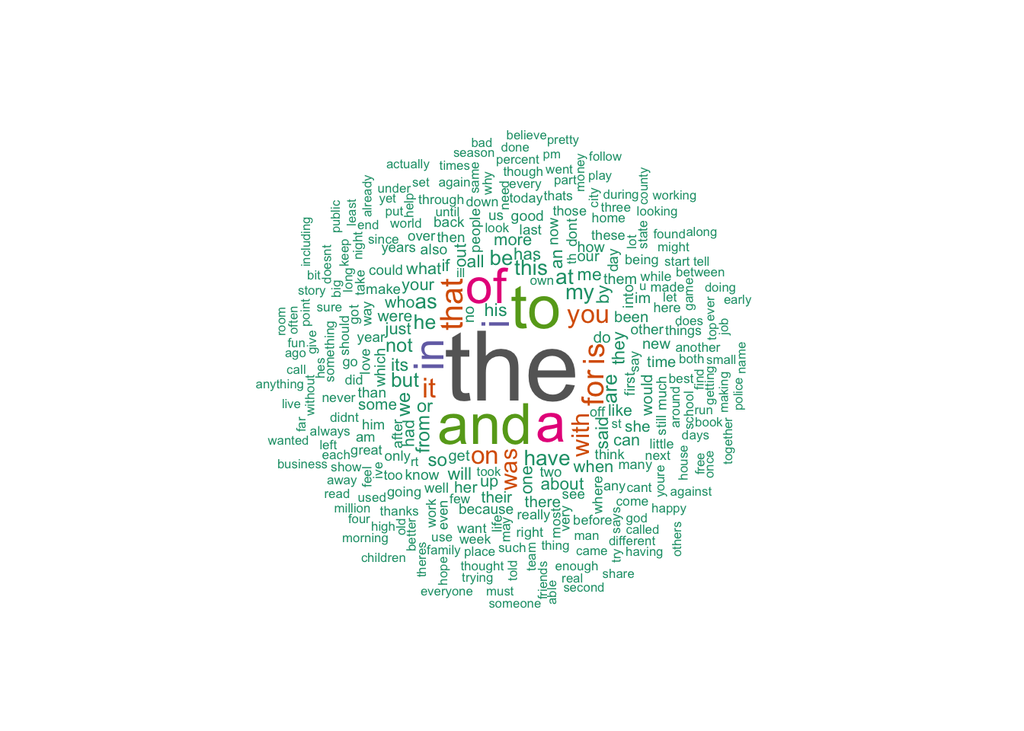

```r
library(RWeka)

ngram.1 <- data.frame(table(NGramTokenizer(corpus.df, Weka_control(min=1, max=1))));

names(ngram.1)[names(ngram.1)=='Var1']<-'Word';

ngram.1 <- ngram.1[order(ngram.1$Freq, decreasing = TRUE),]

wordcloud(words = ngram.1$Word, freq = ngram.1$Freq, min.freq = 1,
          max.words=300, random.order=FALSE, rot.per=0.35,
          colors=brewer.pal(8, "Dark2"))
```

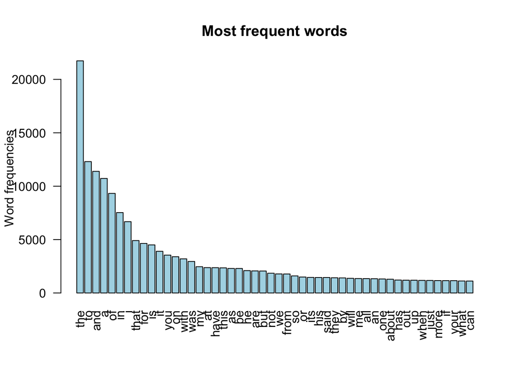

```r
barplot(ngram.1[1:50,]$Freq, las = 2, names.arg = ngram.1[1:50,]$Word,
        col ="lightblue", main ="Most frequent words",
        ylab = "Word frequencies")
```

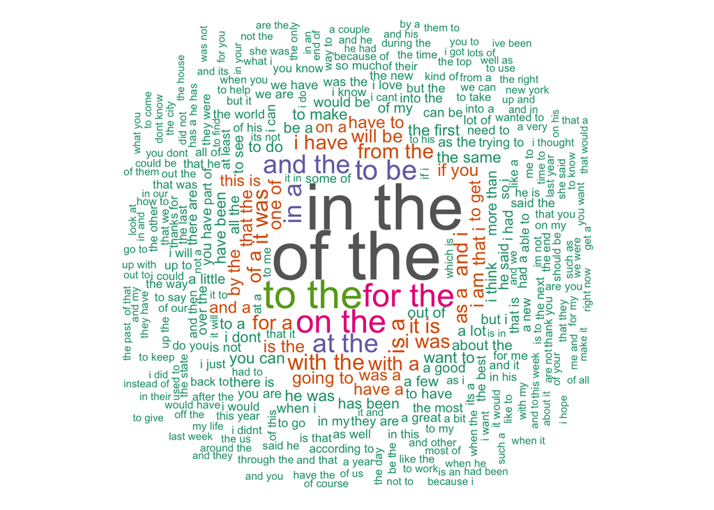

```r
ngram.2 <- data.frame(table(NGramTokenizer(corpus.df, Weka_control(min=2, max=2))));

names(ngram.2)[names(ngram.2)=='Var1']<-'Word';

ngram.2 <- ngram.2[order(ngram.2$Freq, decreasing = TRUE),]

wordcloud(words = ngram.2$Word, freq = ngram.2$Freq, min.freq = 1,
          max.words=300, random.order=FALSE, rot.per=0.35,
          colors=brewer.pal(8, "Dark2"))
```

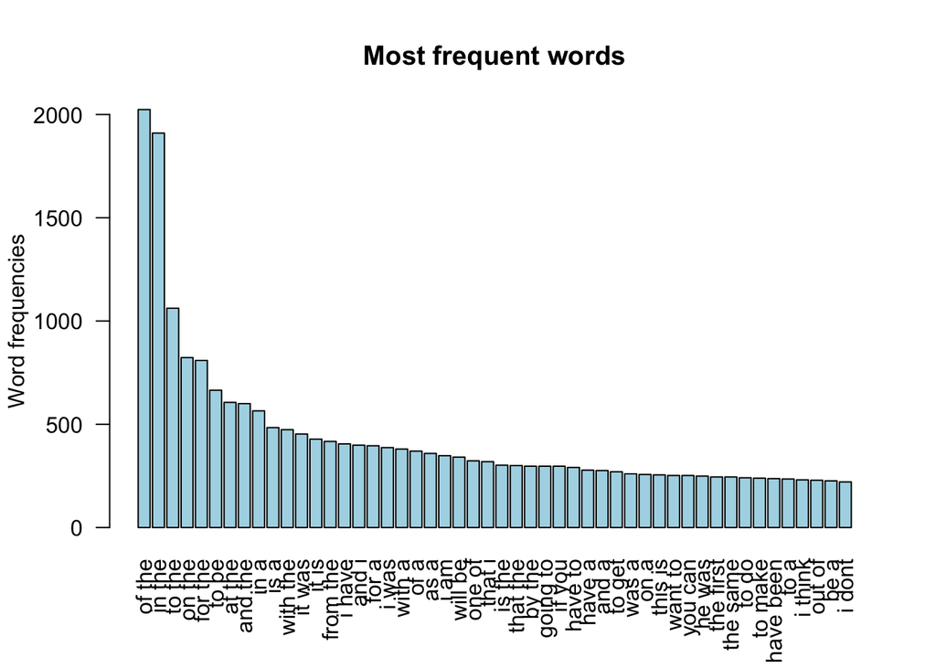

```r
barplot(ngram.2[1:50,]$Freq, las = 2, names.arg = ngram.2[1:50,]$Word,
        col ="lightblue", main ="Most frequent words",
        ylab = "Word frequencies")
```

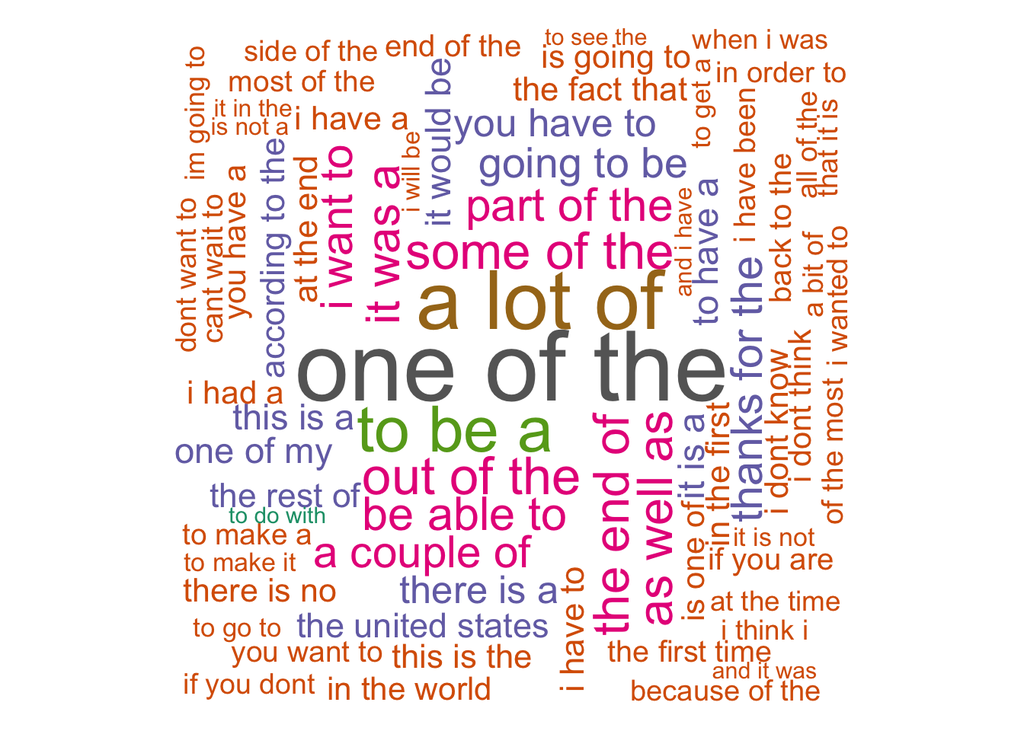

```r
ngram.3 <- data.frame(table(NGramTokenizer(corpus.df, Weka_control(min=3, max=3))))

names(ngram.3)[names(ngram.3)=='Var1']<-'Word';

ngram.3 <- ngram.3[order(ngram.3$Freq, decreasing = TRUE),]

wordcloud(words = ngram.3$Word, freq = ngram.3$Freq, min.freq = 1,
          max.words=150, random.order=FALSE, rot.per=0.35,
          colors=brewer.pal(8, "Dark2"))
```

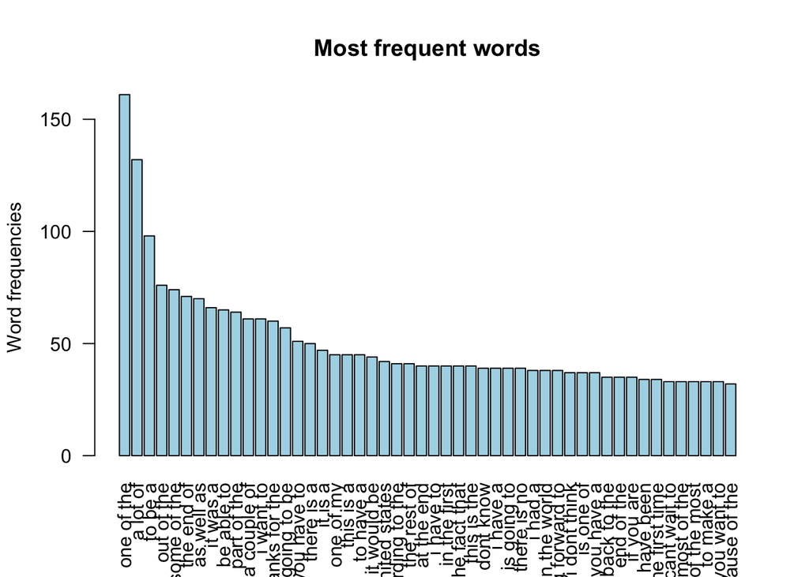

```r
barplot(ngram.3[1:50,]$Freq, las = 2, names.arg = ngram.3[1:50,]$Word,
        col ="lightblue", main ="Most frequent words",
        ylab = "Word frequencies")
```

### Word Dictionary

```r
words.dictionary <- ngram.1 %>%
  mutate(Freq_cumsum = cumsum(Freq)) %>%
  mutate(Dictionary_perc = Freq_cumsum/sum(Freq))
```

### Number of words that form 50% of the dictionary

```r
n_words_50 <- words.dictionary %>%
  group_by(Dictionary_perc >= 0.5) %>%
  mutate(Cut = first(Dictionary_perc)) %>%
  ungroup() %>%
  mutate(Cut = max(Cut)) %>%
  filter(Dictionary_perc <= Cut) %>%
  select(Word, Freq, Dictionary_perc)
```

```r
words_50 <- as.character(n_words_50$Word)

length(words_50)
```

```
[1] 134
```

```r
words_50
```

```
  [1] "the"     "to"      "and"     "a"       "of"      "in"      "i"
  [8] "that"    "for"     "is"      "it"      "you"     "on"      "with"
 [15] "was"     "my"      "at"      "have"    "this"    "as"      "be"
 [22] "he"      "are"     "but"     "not"     "we"      "from"    "so"
 [29] "or"      "its"     "his"     "said"    "they"    "by"      "will"
 [36] "me"      "all"     "an"      "one"     "about"   "has"     "out"
 [43] "up"      "when"    "just"    "more"    "if"      "your"    "what"
 [50] "can"     "had"     "who"     "like"    "were"    "her"     "do"
 [57] "their"   "she"     "some"    "would"   "there"   "been"    "time"
 [64] "get"     "new"     "our"     "no"      "im"      "which"   "them"
 [71] "how"     "now"     "good"    "day"     "people"  "dont"    "know"
 [78] "also"    "into"    "because" "than"    "other"   "after"   "back"
 [85] "us"      "then"    "first"   "over"    "year"    "could"   "him"
 [92] "only"    "last"    "make"    "see"     "two"     "love"    "years"
 [99] "way"     "well"    "much"    "am"      "think"   "really"  "going"
[106] "even"    "where"   "go"      "too"     "life"    "very"    "these"
[113] "any"     "did"     "many"    "still"   "work"    "being"   "great"
[120] "those"   "want"    "most"    "here"    "right"   "got"     "before"
[127] "off"     "little"  "say"     "today"   "made"    "down"    "things"
[134] "while"
```

### Number of words forming 90% of the dictionary

```r
n_words_90 <- words.dictionary %>%
  group_by(Dictionary_perc >= 0.9) %>%
  mutate(Cut = first(Dictionary_perc)) %>%
  ungroup() %>%
  mutate(Cut = max(Cut)) %>%
  filter(Dictionary_perc <= Cut) %>%
  select(Word, Freq, Dictionary_perc)

words_90 <- as.character(n_words_90$Word)

length(words_90)
```

```
[1] 7058
```

# Modeling

```r
require(reshape)
library(RWeka)

generateNgramData <- function(n){
  ngram <- data.frame(table(NGramTokenizer(corpus.df, Weka_control(min=n, max=n))))
  names(ngram)[names(ngram)=='Var1']<-'Word';
  ngram <- ngram[order(ngram$Freq, decreasing = TRUE),]

  if(n == 2) columns <- c('one', 'two')
  if(n == 3) columns <- c('one', 'two', 'three')
  if(n == 4) columns <- c('one', 'two', 'three', 'four')

  if(n > 1) {
    ngram <- transform(ngram, Word = colsplit(Word, split = " ", names = columns ))
  }

  rownames(ngram) <- NULL
  ngram
}

ngram.1 <- generateNgramData(1)
ngram.2 <- generateNgramData(2)
ngram.3 <- generateNgramData(3)
ngram.4 <- generateNgramData(4)
```

The number of unigrams (tokens) is

```r
nrow(ngram.1)
```

```
[1] 35081
```

The number of bigrams (tokens) is

```r
nrow(ngram.2)
```

```
[1] 234414
```

The number of trigrams (tokens) is

```r
nrow(ngram.3)
```

```
[1] 385612
```

We need to perform some transformations on column namess

```r
ngram.2 <- transform(ngram.2, Wordone = Word$one, Wordtwo = Word$two, Word = NULL)
ngram.3 <- transform(ngram.3, Wordone = Word$one, Wordtwo = Word$two, Wordthree = Word$three, Word = NULL)
ngram.4 <- transform(ngram.4, Wordone = Word$one, Wordtwo = Word$two, Wordthree = Word$three, Wordfour = Word$four, Word = NULL)
```

# Simple Back-off Model

### The Algorithm:

A simple quadgram backoff modeling approach, trained on this collection of ngrams, was used to predict a subsequent word. With this approach, a subsequent word is predicted by using progressively shorter histories. For example, let’s say you type “I love the” in order to see what the next predicted word is.

If the model contains a number of words that follow “I love the”, the most frequent terms are suggested.

If the model does not contain any words that follow “I love the”, the first word of the term is backed-off so that the model searches for words that follow “love the”.

If no words exist, the model searches for the most frequent word that follows “the”.

Keep only the First 5 most powerful predictions in the sample. This will help reduce significantly the size of the ngrams data.frames.

```r
ngram.2.sample <- ngram.2 %>%
  group_by(Wordone) %>%
  arrange(Wordone, desc(Freq)) %>%
  filter(row_number() <= 5) %>%
  ungroup()

ngram.3.sample <- ngram.3 %>%
  group_by(Wordone, Wordtwo) %>%
  arrange(Wordone, Wordtwo, desc(Freq)) %>%
  filter(row_number() <= 5) %>%
  ungroup()

ngram.4.sample <- ngram.4 %>%
  group_by(Wordone, Wordtwo, Wordthree) %>%
  arrange(Wordone, Wordtwo, Wordthree, desc(Freq)) %>%
  filter(row_number() <= 5) %>%
  ungroup()


unigramsearch <- function(nb_words = 5, remove_words = "") {
  next_words <-  ngram.1.sample %>%
    filter(!(Word %in% remove_words)) %>%
    filter(row_number() <= nb_words) %>%
    select(Word)

  next_words <- as.vector(next_words$Word)
  next_words
}

bigramsearch <- function(word1, nb_words = 5, remove_words = "") {
  next_words <- ngram.2.sample %>%
    filter(Wordone == word1) %>%
    select(Wordtwo) %>%
    filter(!(Wordtwo %in% remove_words)) %>%
    filter(row_number() <= nb_words)

  next_words <- as.vector(next_words$Wordtwo)

  if(length(next_words) < nb_words)
    next_words <- c(next_words, unigramsearch(nb_words - length(next_words)))

  next_words
}

trigramsearch <- function(word1, word2, nb_words = 5, remove_words = "") {
  next_words <- ngram.3.sample %>%
    filter(Wordone == word1, Wordtwo == word2) %>%
    select(Wordthree) %>%
    filter(!(Wordthree %in% remove_words)) %>%
    filter(row_number() <= nb_words)

  next_words <- as.vector(next_words$Wordthree)

  if(length(next_words) < nb_words)
    next_words <- c(next_words, bigramsearch(word2, nb_words - length(next_words)))

  next_words
}

fourgramsearch <- function(word1, word2, word3, nb_words = 5, remove_words = "") {
  next_words <- ngram.4.sample %>%
    filter(Wordone == word1,
           Wordtwo == word2,
           Wordthree == word3) %>%
    select(Wordfour) %>%
    filter(!(Wordfour %in% remove_words)) %>%
    filter(row_number() <= nb_words)

  next_words <- as.vector(next_words$Wordfour)

  if(length(next_words) < nb_words)
    next_words <- c(next_words, trigramsearch(word2, word3, nb_words - length(next_words)))

  next_words
}


Predictor <- function(text_input) {

  if(nchar(text_input) > 0) {

    corpus_input <- VCorpus(VectorSource(text_input))

    corpus_input<-tm_map(corpus_input, removeNumbers)

    corpus_input<-tm_map(corpus_input, removePunctuation, preserve_intra_word_dashes = TRUE)

    corpus_input<-tm_map(corpus_input, content_transformer(tolower))

    text_input <- sapply(corpus_input, as.character)

    text_input_list = strsplit(text_input, " ")[[1]]

    if(length(text_input_list) == 1){
      # We use bigrams to predict the next word
      next_words <- bigramsearch(text_input_list[1])
    }

    if(length(text_input_list) == 2){
      # We use trigrams to predict the next word
      next_words <- trigramsearch(text_input_list[1], text_input_list[2])
    }

    if(length(text_input_list) >= 3){
      # We use 4 grams to predict the next word
      n = length(text_input_list)
      next_words <- fourgramsearch(text_input_list[n-2], text_input_list[n-1], text_input_list[n])
    }

    next_words <- as.vector(next_words)
    next_words
  }
}
```

### Examples

```r
Predictor("you are so")
```

```
[1] "caught"   "clever"   "colour"   "involved" "so"
```

```r
Predictor("a lot of")
```

```
[1] "the"    "time"   "people" "other"  "things"
```

```r
Predictor("one of the")
```

```
[1] "most"     "greatest" "first"    "best"     "few"
```

```r
Predictor("out of the")
```

```
[1] "way"     "blue"    "closet"  "ground"  "kitchen"
```

```r
Predictor("as well as")
```

```
[1] "the"   "a"     "their" "i"     "some"
```

```r
Predictor("going to be")
```

```
[1] "a"   "in"  "an"  "my"  "the"
```

```r
Predictor("the united states")
```

```
[1] "and" "of"  "but" "has" "we"
```

```r
Predictor("thanks for the")
```

```
[1] "follow"  "rt"      "mention" "ff"      "love"
```

```r
Predictor("it would be")
```

```
[1] "a"         "like"      "difficult" "silly"     "best"
```

```r
Predictor("some of the")
```

```
[1] "most"  "best"  "other" "more"  "words"
```

# Katz’s BackOff Model

Katz’s BackOff Model is useful in N-gram language modeling to estimate the conditional probability of a word, given its history (actually, its preceding words, normally 2-3-4 words). The problem is that the corpus for training must be large to cover as much the diversity of language as possible. Nevertheless, there are cases where “large” is not “large enough”. Katz’s approach is to fall back to lower-order N-gram in this case.

However, one cannot just fall back like this because this naive approach is unfair. Let’s say: A-B-C appears 15 times, while A-B-? totally appear 100 times. As a result, Probability(A-B-C|A-B) = 15%. But A-B-N does not appear, so we fall back to B-N and similarly, find that Probability(B-N|B) = 40%. It is unfair because “A-B” gives more context than just “B”, but it is NOT chosen!

Katz fixes this issue by redistributing some probability of high-order N-gram to lower-order N-gram, so that all of the probabilities accumulate to 1. But first we have to reap some probability of the high-order N-gram, making it available to lower-order N-gram. It is done by using Good-Turing Discounting.

After having some left-over probability for lower-order N-gram, we distribute it fairly. That is, in the lower-order N-gram, the N-grams who have more probability to appear will have more share in this left-over probability.

The Katz’s approach makes sense.

This model generally works well in practice, but fails in some circumstances. For example, suppose that the bigram “a b” and the unigram “c” are very common, but the trigram “a b c” is never seen. Since “a b” and “c” are very common, it may be significant (that is, not due to chance) that “a b c” is never seen. Perhaps it’s not allowed by the rules of the grammar. Instead of assigning a more appropriate value of 0, the method will back off to the bigram and estimate P(c | b), which may be too high.

Wikipedia provides a good explanation for equations to be used later:

https://en.wikipedia.org/wiki/Katz%27s_back-off_model

```r
library(edgeR)
library(plyr)

GoodTuringProportions <- function(frequency){
  goodTuringProportions(frequency)[,1]
}

GoodTuringAlpha <- function(frequency){
  goodTuring(frequency)$P0
}
```

Calculate the P_ml for unigrams.

P_ml is the probability calculated using the maximum likelihood estimation.

```r
ngram.1.sample <- ngram.1 %>%
  mutate(P_ml = Freq/sum(Freq), P_ml_sum = sum(P_ml)) %>%
  dplyr::filter(row_number() <= 5)
```

For bigrams, trigrams and fourgrams, we need to calculate back-off probabilities by group and α, α is the probability estimated combined proportion of all undetected species by group. We then keep only the first 5 rows of a group as we will not predict more than 5 words. This will significantly reduce the size of the used sets of prediction.

In this model, there is a simple approximation used:

${\sum _{{\{w_{i}:C(w_{{i-n+1}}\cdots w_{{i}})\leq k\}}}P_{{bo}}(w_{i}\mid w_{{i-n+2}}\cdots w_{{i-1}})}$ is substitued byn${\sum _{{w_{i}}P_{{bo}}(w_{i}\mid w_{{i-n+2}}\cdots w_{{i-1}})}}$.

∑ P_bo is used over all words instead of ∑ P_bo such that C <= k.

```r
ngram.2.sample <- ngram.2 %>%
  dplyr::group_by(Wordone) %>%
  dplyr::mutate(P_ml = Freq/sum(Freq), P_bo = GoodTuringProportions(Freq),
                alpha = GoodTuringAlpha(Freq), P_bo_sum = sum(P_bo)) %>%
  dplyr::arrange(Wordone, desc(Freq)) %>%
  dplyr::filter(row_number() <= 5) %>%
  dplyr::ungroup()

ngram.3.sample <- ngram.3 %>%
  dplyr::group_by(Wordone, Wordtwo) %>%
  dplyr::mutate(P_ml = Freq/sum(Freq), P_bo = GoodTuringProportions(Freq),
                alpha = GoodTuringAlpha(Freq), P_bo_sum = sum(P_bo)) %>%
  dplyr::arrange(Wordone, Wordtwo, desc(Freq)) %>%
  dplyr::filter(row_number() <= 5) %>%
  dplyr::ungroup()

ngram.4.sample <- ngram.4 %>%
  dplyr::group_by(Wordone, Wordtwo, Wordthree) %>%
  dplyr::mutate(P_ml = Freq/sum(Freq), P_bo = GoodTuringProportions(Freq),
                alpha = GoodTuringAlpha(Freq), P_bo_sum = sum(P_bo)) %>%
  dplyr::arrange(Wordone, Wordtwo, Wordthree, desc(Freq)) %>%
  dplyr::filter(row_number() <= 5) %>%
  dplyr::ungroup()
```

```r
katz.backoff.ngram.2.search <- function(word1, nb_words = 5, remove_words = ""){

  # We filter ngram.2 to include only bigrams such that wordone is the text_input
  ngram.2.f <- ngram.2.sample %>%
    dplyr::filter(Wordone == word1)

  if(nrow(ngram.2.f) > 0){
    alpha.2 <- ngram.2.f$alpha[1]
  } else{
    alpha.2 <- 1
  }

  # If all bigrams have the same count with n=1, the assocaited P_bo will be NA,
  # the probability estimated combined proportion of all undetected species is 1
  # these elements should be filtered, so that they are not removed from the unigrams when c <= k

  # If all bigrams have the same count with n>1, the assocaited P_bo will be NA,
  # the probability estimated combined proportion of all undetected species is 0
  # P_bo should be then replaced with P_ML

  ngram.2.f <- ngram.2.f %>%
    dplyr::filter(!(is.na(P_bo) & alpha == 1)) %>%
    dplyr::mutate(P_bo = ifelse(is.na(P_bo) & alpha == 0, P_ml, P_bo))

  # We filter ngram.2 to include only Words that don't appear as Wordtwo in the filtered bigrams
  ngram.1.f <- ngram.1.sample %>%
    dplyr::filter(! (Word %in% ngram.2.f$Wordtwo))

  # We add the discounted probability (backoff probability) α q_ML / ∑ q_ML
  ngram.1.f <- ngram.1.f %>%
    dplyr::mutate(P_bo = alpha.2*(P_ml/P_ml_sum)) %>%
    dplyr::rename(Wordtwo = Word)

  next_words <- rbind.fill(ngram.2.f, ngram.1.f) %>%
    arrange(desc(P_bo)) %>%
    select(Wordtwo) %>%
    filter(!(Wordtwo %in% remove_words)) %>%
    filter(row_number() <= nb_words)

  next_words <- as.vector(next_words$Wordtwo)
  next_words
}


katz.backoff.ngram.3.search <- function(word1, word2, nb_words = 5, remove_words = "") {

  # We filter ngram.3 to include only bigrams such that wordone and wordtwo is the text_input
  ngram.3.f <- ngram.3.sample %>%
    dplyr::filter(Wordone == word1, Wordtwo == word2)

  if(nrow(ngram.3.f) > 0){
    alpha.3 <- ngram.3.f$alpha[1]
  } else{
    alpha.3 <- 1
  }

  # We add the discounted probability (backoff probability) c*/c to the bigram words (k>0)
  ngram.3.f <- ngram.3.f %>%
    dplyr::filter(!(is.na(P_bo) & alpha == 1)) %>%
    dplyr::mutate(P_bo = ifelse(is.na(P_bo) & alpha == 0, P_ml, P_bo))

  # If all trigrams have the same count with n=1, the assocaited P_bo will be NA,
  # the probability estimated combined proportion of all undetected species is 1
  # these elements should be filtered, so that they are not removeed from the bigrams

  # If all trigrams have the same count with n>1, the assocaited P_bo will be NA,
  # the probability estimated combined proportion of all undetected species is 0
  # P_bo should be then replaced with P_ML

  # We filter ngram.2 to include only bigrams such that wordone is the text_input
  ngram.2.f <- ngram.2.sample %>%
    dplyr::filter(Wordone == word2)

  # We filter ngram.2 to include only Words that don't appear as Wordtwo in the filtered bigrams
  ngram.2.f <- ngram.2.f %>%
    dplyr::filter(!(Wordtwo %in% ngram.3.f$Wordthree))

  # We recalculate the discounted probability (backoff probability) α P_bo / ∑ P_bo
  ngram.2.f <- ngram.2.f %>%
    dplyr::mutate(P_bo = alpha.3*(P_bo/P_bo_sum)) %>%
    dplyr::rename(Wordthree = Wordtwo, Wordtwo = Wordone)

  next_words <- rbind.fill(ngram.3.f, ngram.2.f) %>%
    dplyr::arrange(desc(P_bo)) %>%
    dplyr::select(Wordthree) %>%
    dplyr::filter(!(Wordthree %in% remove_words)) %>%
    dplyr::filter(row_number() <= nb_words)

  next_words <- as.vector(next_words$Wordthree)

  if(length(next_words) < nb_words)
    next_words <- c(next_words, katz.backoff.ngram.2.search(word2, nb_words - length(next_words)))

  next_words
}


katz.backoff.ngram.4.search <- function(word1, word2, word3, nb_words = 5, remove_words = "") {

  # We filter ngram.3 to include only bigrams such that wordone and wordtwo is the text_input
  ngram.4.f <- ngram.4.sample %>%
    dplyr::filter(Wordone == word1, Wordtwo == word2, Wordthree == word3)

  if(nrow(ngram.4.f) > 0){
    alpha.4 <- ngram.4.f$alpha[1]
  } else{
    alpha.4 <- 1
  }

  # We add the discounted probability (backoff probability) c*/c to the bigram words (k>0)
  ngram.4.f <- ngram.4.f %>%
    dplyr::filter(!(is.na(P_bo) & alpha == 1)) %>%
    dplyr::mutate(P_bo = ifelse(is.na(P_bo) & alpha == 0, P_ml, P_bo))

  # If all trigrams have the same count with n=1, the assocaited P_bo will be NA,
  # the probability estimated combined proportion of all undetected species is 1
  # these elements should be filtered, so that they are not removeed from the bigrams

  # If all trigrams have the same count with n>1, the assocaited P_bo will be NA,
  # the probability estimated combined proportion of all undetected species is 0
  # P_bo should be then replaced with P_ML

  # We filter ngram.2 to include only bigrams such that wordone is the text_input
  ngram.3.f <- ngram.3.sample %>%
    dplyr::filter(Wordone == word2, Wordtwo == word3)

  # We filter ngram.2 to include only Words that don't appear as Wordtwo in the filtered bigrams
  ngram.3.f <- ngram.3.f %>%
    dplyr::filter(!(Wordthree %in% ngram.4.f$Wordfour))

  # We recalculate the discounted probability (backoff probability) α P_bo / ∑ P_bo
  ngram.3.f <- ngram.3.f %>%
    dplyr::mutate(P_bo = alpha.4*(P_bo/P_bo_sum)) %>%
    dplyr::rename(Wordfour = Wordthree, Wordthree = Wordtwo, Wordtwo = Wordone)

  next_words <- rbind.fill(ngram.4.f, ngram.3.f) %>%
    dplyr::arrange(desc(P_bo)) %>%
    dplyr::select(Wordfour) %>%
    dplyr::filter(!(Wordfour %in% remove_words)) %>%
    dplyr::filter(row_number() <= nb_words)

  next_words <- as.vector(next_words$Wordfour)

  if(length(next_words) < nb_words)
    next_words <- c(next_words, katz.backoff.ngram.3.search(word2, word3, nb_words - length(next_words)))

  next_words
}


Predictor <- function(text_input) {

  if(nchar(text_input) > 0) {

    corpus_input <- VCorpus(VectorSource(text_input))

    corpus_input<-tm_map(corpus_input, removeNumbers)

    corpus_input<-tm_map(corpus_input, removePunctuation, preserve_intra_word_dashes = TRUE)

    corpus_input<-tm_map(corpus_input, content_transformer(tolower))

    text_input <- sapply(corpus_input, as.character)

    text_input_list = strsplit(text_input, " ")[[1]]

    if(length(text_input_list) == 1){
      # We use bigrams and unigrams to predict the next word

      next_words <- katz.backoff.ngram.2.search(text_input_list[1])
    }

    if(length(text_input_list) == 2){
      # We use trigrams and bigrams to predict the next word

      next_words <- katz.backoff.ngram.3.search(text_input_list[1], text_input_list[2])
    }

    if(length(text_input_list) >= 3){

      # We use fourgrams and trigrams to predict the next word
      n = length(text_input_list)

      next_words <- katz.backoff.ngram.4.search(text_input_list[n-2], text_input_list[n-1], text_input_list[n])
    }
    return(next_words)
  }
}
```

### Examples

```r
Predictor("you are so")
```

```
[1] "many"        "clever"      "caught"      "colour"      "complicated"
```

```r
Predictor("a lot of")
```

```
[1] "the"    "time"   "people" "other"  "things"
```

```r
Predictor("one of the")
```

```
[1] "most"     "greatest" "first"    "best"     "few"
```

```r
Predictor("out of the")
```

```
[1] "way"  "most" "day"  "year" "blue"
```

```r
Predictor("as well as")
```

```
[1] "the"   "a"     "their" "for"   "i"
```

```r
Predictor("going to be")
```

```
[1] "a"    "in"   "an"   "able" "my"
```

```r
Predictor("the united states")
```

```
[1] "is"  "and" "of"  "but" "has"
```

```r
Predictor("thanks for the")
```

```
[1] "follow"  "rt"      "mention" "ff"      "first"
```

```r
Predictor("it would be")
```

```
[1] "a"         "like"      "difficult" "the"       "silly"
```

```r
Predictor("some of the")
```

```
[1] "most"  "best"  "other" "day"   "year"
```